# Introduction to R and the tidyverse

## summarise your data: `summarize()`

- if you want to create aggregations and summary fo your data
- you cna use `summarize(data, newvar = f(oldvar))`
- it works similarly to `mutate()` but it returns a **scalar**

```r
summarize(df, meandelay = mean(dep_delay, na.rm = TRUE))
```

```
## # A tibble: 1 x 1
##   meandelay
##       <dbl>
## 1      12.6
```

## `summarize()` properties

- you can do more than one summary in one go

```r
summarize(df, meandelay = mean(dep_delay, na.rm = TRUE), sddelay = sd(dep_delay, na.rm = TRUE), meandeptime = mean(dep_time, na.rm = TRUE))
```

```
## # A tibble: 1 x 3
##   meandelay sddelay meandeptime
##       <dbl>   <dbl>       <dbl>
## 1      12.6    40.2       1349.
```

## making `summarize()` more useful: `group_by()`

> `summarize()` is not so useful -> one value
- but it can be extremely useful if we can group data by a special variable, to see, e.g., monthly values
- this is what you do with `group_by()`
- which groups the data frame by levels of one (or more) variablesn
- nothing changes but now R knows this is a grouped data frame

```r
group_by(df, month)
```

```
## # A tibble: 336,776 x 19
## # Groups:   month [12]
##     year month   day dep_time sched_dep_time dep_delay arr_time sched_arr_time
##    <int> <int> <int>    <int>          <int>     <dbl>    <int>          <int>
##  1  2013     1     1      517            515         2      830            819
##  2  2013     1     1      533            529         4      850            830
##  3  2013     1     1      542            540         2      923            850
##  4  2013     1     1      544            545        -1     1004           1022
##  5  2013     1     1      554            600        -6      812            837
##  6  2013     1     1      554            558        -4      740            728
##  7  2013     1     1      555            600        -5      913            854
##  8  2013     1     1      557            600        -3      709            723
##  9  2013     1     1      557            600        -3      838            846
## 10  2013     1     1      558            600        -2      753            745
## # … with 336,766 more rows, and 11 more variables: arr_delay <dbl>,
## #   carrier <chr>, flight <int>, tailnum <chr>, origin <chr>, dest <chr>,
## #   air_time <dbl>, distance <dbl>, hour <dbl>, minute <dbl>, time_hour <dttm>
```

## example: delay by month

- output has 12 rows

```r
df_bymonth <- group_by(df, month)
summarize(df_bymonth, meandelay = mean(dep_delay, na.rm = TRUE))
```

```
## # A tibble: 12 x 2
##    month meandelay
##    <int>     <dbl>
##  1     1     10.0
##  2     2     10.8
##  3     3     13.2
##  4     4     13.9
##  5     5     13.0
##  6     6     20.8
##  7     7     21.7
##  8     8     12.6
##  9     9      6.72
## 10    10      6.24
## 11    11      5.44
## 12    12     16.6
```

## example: delay by month **and** day

- output has 365 rows

```r
df_bymonth_byday <- group_by(df, month, day)
summarise(df_bymonth_byday, meandelay = mean(dep_delay, na.rm = TRUE))
```

```
## # A tibble: 365 x 3
## # Groups:   month [12]
##    month   day meandelay
##    <int> <int>     <dbl>
##  1     1     1     11.5
##  2     1     2     13.9
##  3     1     3     11.0
##  4     1     4      8.95
##  5     1     5      5.73
##  6     1     6      7.15
##  7     1     7      5.42
##  8     1     8      2.55
##  9     1     9      2.28
## 10     1    10      2.84
## # … with 355 more rows
```

## Exercise: a complex example

> **what is the speed of flights departing around midday (11 - 13), by month?**
- the input is the flights df
- use `filter()`, `select()`, `mutate()`, `group_by()` and `summarize()`
- the final output is a df with 2 variables (month and speed) and 12 observations (one for each month)

> *à vous de jouer!*

## A somewhat more complex example

- let’s combine `filter()`, `select()`, `mutate()`, etc…
- we want to know the average speed of flights departing around midday, by month

```r
df_midday <- filter(df, dep_time > 1100 & dep_time < 1300)
df_midday_reduced <- select(df_midday, month, air_time, distance)
df_midday_speed <- mutate(df_midday_reduced,
                          speed = distance / air_time * 60)
df_midday_grouped <- group_by(df_midday_speed, month)
df_midday_final <- summarise(df_midday_grouped,
                             meanspeed = mean(speed, na.rm = TRUE))
df_midday_final
```

```
## # A tibble: 12 x 2
##    month meanspeed
##    <int>     <dbl>
##  1     1      365.
##  2     2      369.
##  3     3      385.
##  4     4      385.
##  5     5      401.
##  6     6      397.
##  7     7      401.
##  8     8      397.
##  9     9      407.
## 10    10      393.
## 11    11      379.
## 12    12      373.
```

## Multiple operations: problems

> the code in the previous slide has several problems
- it forces you to create several different data frames
- this clutters your environment
- but not only: at each step, you have to refer to the *right* data frame
- else you make mistake
- hard to find proper names
- easy to make errors
- what can we do?

## Enters the pipe! `%>%`

> the *pipe* operator
- feeds the *result* of a command as the *first argument* of the following command

```r
2*2
```

```
## [1] 4
```

```r
exp(4)
```

```
## [1] 54.59815
```

```r
(2*2) %>% exp()
```

```
## [1] 54.59815
```

- since *dplyr* verbs always return a data frame, and always have a data frame as first input, this saves your life

## the same code with the pipe

```r
df_midday  %>%  filter(dep_time > 1100 & dep_time < 1300) %>%
                select(month, air_time, distance) %>%
                mutate(speed = distance / air_time * 60) %>%
                group_by(month) %>%
                summarise(meanspeed = mean(speed, na.rm = TRUE))
```

```
## # A tibble: 12 x 2
##    month meanspeed
##    <int>     <dbl>
##  1     1      365.
##  2     2      369.
##  3     3      385.
##  4     4      385.
##  5     5      401.
##  6     6      397.
##  7     7      401.
##  8     8      397.
##  9     9      407.
## 10    10      393.
## 11    11      379.
## 12    12      373.
```

## Learning to use the pipe

- what is the mean delay of flights by carrier, for each month?
- what is the maximum departure delay occurred for each of the three NYC airports, by each day?
- what is the mean air time for each of these three airports? from which airport do the longer haul flights depart?

## combining the pipe with a plot

> you can add a ggplot at the end of the pipe
- ggplot does not work with the pipe, it uses `+` as we know
- so it must come last of the pipe
- try to show barplots showing graphically the results of the questions in the previous slides

## Joining datasets

## data scattered around

> you do not always have all the data you need in *one* dataset
- it is usually scattered around several datasets
- that might or might not be linked / linkable
- e.g. you might need to merge data coming from different sources (INSEE and Eurostat)
- or you might do some computations / summarize and would like to merge these back

## using the `nycflights13` dataset again

- planes

```r
library(nycflights13)
planes <- nycflights13::planes
planes
```

```
## # A tibble: 3,322 x 9
##    tailnum  year type          manufacturer   model  engines seats speed engine
##    <chr>   <int> <chr>         <chr>          <chr>    <int> <int> <int> <chr>
##  1 N10156   2004 Fixed wing m… EMBRAER        EMB-1…       2    55    NA Turbo-…
##  2 N102UW   1998 Fixed wing m… AIRBUS INDUST… A320-…       2   182    NA Turbo-…
##  3 N103US   1999 Fixed wing m… AIRBUS INDUST… A320-…       2   182    NA Turbo-…
##  4 N104UW   1999 Fixed wing m… AIRBUS INDUST… A320-…       2   182    NA Turbo-…
##  5 N10575   2002 Fixed wing m… EMBRAER        EMB-1…       2    55    NA Turbo-…
##  6 N105UW   1999 Fixed wing m… AIRBUS INDUST… A320-…       2   182    NA Turbo-…
##  7 N107US   1999 Fixed wing m… AIRBUS INDUST… A320-…       2   182    NA Turbo-…
##  8 N108UW   1999 Fixed wing m… AIRBUS INDUST… A320-…       2   182    NA Turbo-…
##  9 N109UW   1999 Fixed wing m… AIRBUS INDUST… A320-…       2   182    NA Turbo-…
## 10 N110UW   1999 Fixed wing m… AIRBUS INDUST… A320-…       2   182    NA Turbo-…
## # … with 3,312 more rows
```

## using the `nycflights13` dataset again

- airports

```r
airports <- nycflights13::airports
airports
```

```
## # A tibble: 1,458 x 8
##    faa   name                       lat    lon   alt    tz dst   tzone
##    <chr> <chr>                    <dbl>  <dbl> <dbl> <dbl> <chr> <chr>
##  1 04G   Lansdowne Airport         41.1  -80.6  1044    -5 A     America/New_Yo…
##  2 06A   Moton Field Municipal A…  32.5  -85.7   264    -6 A     America/Chicago
##  3 06C   Schaumburg Regional       42.0  -88.1   801    -6 A     America/Chicago
##  4 06N   Randall Airport           41.4  -74.4   523    -5 A     America/New_Yo…
##  5 09J   Jekyll Island Airport     31.1  -81.4    11    -5 A     America/New_Yo…
##  6 0A9   Elizabethton Municipal …  36.4  -82.2  1593    -5 A     America/New_Yo…
##  7 0G6   Williams County Airport   41.5  -84.5   730    -5 A     America/New_Yo…
##  8 0G7   Finger Lakes Regional A…  42.9  -76.8   492    -5 A     America/New_Yo…
##  9 0P2   Shoestring Aviation Air…  39.8  -76.6  1000    -5 U     America/New_Yo…
## 10 0S9   Jefferson County Intl     48.1 -123.    108    -8 A     America/Los_An…
## # … with 1,448 more rows
```

## using the `nycflights13` dataset again

- flights

```r
flights <- nycflights13::flights
flights
```

```
## # A tibble: 336,776 x 19
##     year month   day dep_time sched_dep_time dep_delay arr_time sched_arr_time
##    <int> <int> <int>    <int>          <int>     <dbl>    <int>          <int>
##  1  2013     1     1      517            515         2      830            819
##  2  2013     1     1      533            529         4      850            830
##  3  2013     1     1      542            540         2      923            850
##  4  2013     1     1      544            545        -1     1004           1022
##  5  2013     1     1      554            600        -6      812            837
##  6  2013     1     1      554            558        -4      740            728
##  7  2013     1     1      555            600        -5      913            854
##  8  2013     1     1      557            600        -3      709            723
##  9  2013     1     1      557            600        -3      838            846
## 10  2013     1     1      558            600        -2      753            745
## # … with 336,766 more rows, and 11 more variables: arr_delay <dbl>,
## #   carrier <chr>, flight <int>, tailnum <chr>, origin <chr>, dest <chr>,
## #   air_time <dbl>, distance <dbl>, hour <dbl>, minute <dbl>, time_hour <dttm>
```

## inspect the datasets

> what do these dataset contain?
- what variables do they have in common?
- do they have some unique identifier (`key`)?
- how are these related to one another?

## the datasets

- *planes* has information on each plane (model, type, date of construction…)
- *airports* has information on each airport (faa code, location, lat, long )
- *flights* has information on each flight that left/landed in a NYC airport

## joining different datasets: example

> problem: do newer planes fly the longest routes from NYC?
- to answer this, you need to combine data from two sources:
- *flights* to get the route’s length in terms of miles
- *planes* to get the date the plane was first operational

> how do you *join* the two data frames?

## joining two datasets: **key**

- *first* you need to find a *unique identifier* for your data: a **key**
- unique identifiers have the characteristics of being unique in the whole dataset
- in order to find them, either you use your intuition
- or you check

```r
planes %>% count(tailnum) %>% filter(n>1)
```

```
## # A tibble: 0 x 2
## # … with 2 variables: tailnum <chr>, n <int>
```

- `count(var)` gives the count of how many times each element of `var` appears as a new variable `n`
- by filtering for just `n>1` you check if any value appears twice

## joining

> once you know the key, you can use the `join` family of functions
- imagine you have two datasets with variables and values as follows:

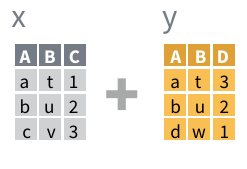

- there is some overlapping information on the two tables
- but there is also new information
- column D only in dataset Y
- row ‘c’ only in dataset X; row ‘d’ only in dataset Y

## joining

> joining always combines data from *two* tables into *one*
- syntax alays the same: `join(left, right, by = "key")`
- *left* and *right* two data frames
- *key* the unique identifier of obsevations (in one or both data frames)

## the joining family

- different `join` functions make different assumptions about what to do of the data that are NOT matched

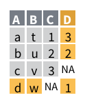

- `full_join()` keeps everything, adds `NA`
- `inner_join()` keeps only matched data

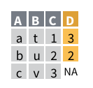

- `left_join()` keeps *all* keys in the *left* df

## the default `left_join()`

> `left_join()` is the default because you usually add *some* variable to a large dataset
- in our case: * do newer planes fly the longest routes from NYC?*
- we have most information on the *flights* dataset
- we need only the year built from the *planes* dataset

## answering our question – joining

```r
distance <- flights %>% select(tailnum, distance)
yearbuilt <- planes %>% select(tailnum, year)
answer <- left_join(distance, yearbuilt, by = "tailnum")
answer
```

```
## # A tibble: 336,776 x 3
##    tailnum distance  year
##    <chr>      <dbl> <int>
##  1 N14228      1400  1999
##  2 N24211      1416  1998
##  3 N619AA      1089  1990
##  4 N804JB      1576  2012
##  5 N668DN       762  1991
##  6 N39463       719  2012
##  7 N516JB      1065  2000
##  8 N829AS       229  1998
##  9 N593JB       944  2004
## 10 N3ALAA       733    NA
## # … with 336,766 more rows
```

## answering our question: the answer

- there does not seem to be any connection beteen the year and the length of the flight

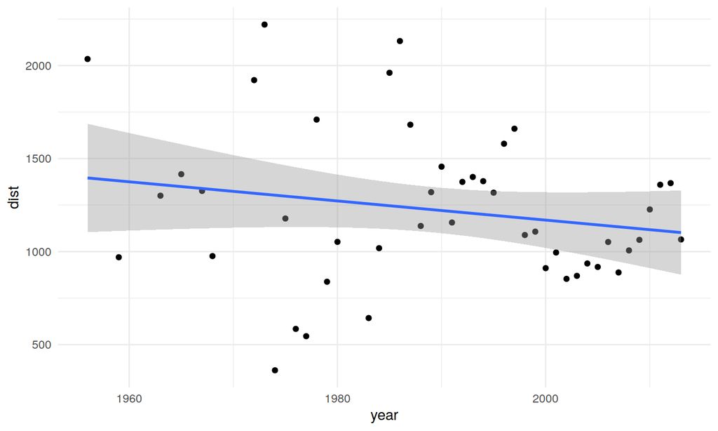

```r
answer %>% group_by(year) %>%
  summarise(dist = mean(distance, na.rm = TRUE)) %>%
  ggplot(aes(x = year, y = dist))+geom_point()+
  geom_smooth(method = "lm")
```

## joining exercise

> how many flights through NYC land in an airport whose altitude is > 1000mt?
- note: 1 mètre = 3,28084 mètres
- altitude is in the *airports* df
- flights are in the *flights* df

## solution

- a lot of flights, since denver sits at 1600mt!

```r
alt_df <- airports %>% select(faa,alt) %>% mutate(alt = alt/3.28024) %>% rename(dest = faa)
answer <- left_join(flights, alt_df, by = "dest") %>% filter(alt>1000)
answer
```

```
## # A tibble: 10,291 x 20
##     year month   day dep_time sched_dep_time dep_delay arr_time sched_arr_time
##    <int> <int> <int>    <int>          <int>     <dbl>    <int>          <int>
##  1  2013     1     1      646            645         1      910            916
##  2  2013     1     1      655            655         0     1021           1030
##  3  2013     1     1      727            730        -3      959            952
##  4  2013     1     1      752            750         2     1025           1029
##  5  2013     1     1      754            755        -1     1103           1030
##  6  2013     1     1      813            815        -2     1103           1056
##  7  2013     1     1      833            835        -2     1134           1102
##  8  2013     1     1      848            851        -3     1155           1136
##  9  2013     1     1      906            843        23     1134           1125
## 10  2013     1     1      926            928        -2     1233           1220
## # … with 10,281 more rows, and 12 more variables: arr_delay <dbl>,
## #   carrier <chr>, flight <int>, tailnum <chr>, origin <chr>, dest <chr>,
## #   air_time <dbl>, distance <dbl>, hour <dbl>, minute <dbl>, time_hour <dttm>,
## #   alt <dbl>
```

## joining three datasets

> how old are the planes that fly to airports whose altitude is >1000mt?

## joining three datasets, solution

```r
answer <- left_join(flights,yearbuilt, by = "tailnum")
answer <- left_join(answer, alt_df, by = "dest")
answer %>% filter(alt>1000) %>% summarise(avgyear = mean(year.y, na.rm = TRUE))
```

```
## # A tibble: 1 x 1
##   avgyear
##     <dbl>
## 1   2000.
```

```r
answer %>% filter(alt<=1000) %>% summarise(avgyear = mean(year.y, na.rm = TRUE))
```

```
## # A tibble: 1 x 1
##   avgyear
##     <dbl>
## 1   2001.
```

## tidy data

## messy data -> tidy data

> “Happy families are all alike; every unhappy family is unhappy in its own way.” –– Leo Tolstoy
- the data we have worked with so far are all well formatted
- this is *not* the case in real life
- we need to be able to *format data in a convenint way*
- if you work with the tools we’ve seen (`dplyr`, `ggplot2`) then you want *tidy* data

## a simple dataset in four versions

```r
table1
```

```
## # A tibble: 6 x 4
##   country      year  cases population
##   <chr>       <int>  <int>      <int>
## 1 Afghanistan  1999    745   19987071
## 2 Afghanistan  2000   2666   20595360
## 3 Brazil       1999  37737  172006362
## 4 Brazil       2000  80488  174504898
## 5 China        1999 212258 1272915272
## 6 China        2000 213766 1280428583
```

## a simple dataset in four versions

```r
table2
```

```
## # A tibble: 12 x 4
##    country      year type            count
##    <chr>       <int> <chr>           <int>
##  1 Afghanistan  1999 cases             745
##  2 Afghanistan  1999 population   19987071
##  3 Afghanistan  2000 cases            2666
##  4 Afghanistan  2000 population   20595360
##  5 Brazil       1999 cases           37737
##  6 Brazil       1999 population  172006362
##  7 Brazil       2000 cases           80488
##  8 Brazil       2000 population  174504898
##  9 China        1999 cases          212258
## 10 China        1999 population 1272915272
## 11 China        2000 cases          213766
## 12 China        2000 population 1280428583
```

## a simple dataset in four versions

```r
table3
```

```
## # A tibble: 6 x 3
##   country      year rate
## * <chr>       <int> <chr>
## 1 Afghanistan  1999 745/19987071
## 2 Afghanistan  2000 2666/20595360
## 3 Brazil       1999 37737/172006362
## 4 Brazil       2000 80488/174504898
## 5 China        1999 212258/1272915272
## 6 China        2000 213766/1280428583
```

## a simple dataset in four versions

```r
table4a  #cases
```

```
## # A tibble: 3 x 3
##   country     `1999` `2000`
## * <chr>        <int>  <int>
## 1 Afghanistan    745   2666
## 2 Brazil       37737  80488
## 3 China       212258 213766
```

```r
table4b  #population
```

```
## # A tibble: 3 x 3
##   country         `1999`     `2000`
## * <chr>            <int>      <int>
## 1 Afghanistan   19987071   20595360
## 2 Brazil       172006362  174504898
## 3 China       1272915272 1280428583
```

## tidy, untidy data

> tidy dat has the following characteristics:
- each variable has its own column
- each observation has its own row
- each value has its own cell

> have a look at the tables.
- what is an observation?
- what is a variable?
- do you see problems in the tables?

## tidy data: the `tidyr` package

- `tidyr` is part fo the tidyverse
- it is automatically loaded with `library(tidyverse)`
- `tidyr` provides 4 main verbs
- `gather` vs. `spread`
- `separate` vs. `unite`

## gathering: from wide to long

> sometimes variables are in the column names: bad!

```r
table4a
```

```
## # A tibble: 3 x 3
##   country     `1999` `2000`
## * <chr>        <int>  <int>
## 1 Afghanistan    745   2666
## 2 Brazil       37737  80488
## 3 China       212258 213766
```

- ‘year’ is a variable but it is on the column names
- content is ‘cases’ but has no variable name

## gathering

> we need to reshape the data from *wide* to *long*, so that *year* becomes a variable and *1999* and *2000* become values.
- we use `gather(vars, key, value)`
- `vars` is the variable names that are not actually variables but values
- `key` is the (new) name to be given to the (new) column that will be created to store the (former) variable names
- `value` is the (new) name to be given to the (new) column that will be created to store the values that were spread over several variables

## gathering

> what happens if we just provide NO arguments?
- everything is gathered just two columns left (key & value)

```r
table4a %>% gather()
```

```
## # A tibble: 9 x 2
##   key     value
##   <chr>   <chr>
## 1 country Afghanistan
## 2 country Brazil
## 3 country China
## 4 1999    745
## 5 1999    37737
## 6 1999    212258
## 7 2000    2666
## 8 2000    80488
## 9 2000    213766
```

## gathering

> what if we provide arguments?

```r
cases <- table4a %>% gather(`1999`,`2000`, key = year, value = cases) %>% arrange(country, year)
cases
```

```
## # A tibble: 6 x 3
##   country     year   cases
##   <chr>       <chr>  <int>
## 1 Afghanistan 1999     745
## 2 Afghanistan 2000    2666
## 3 Brazil      1999   37737
## 4 Brazil      2000   80488
## 5 China       1999  212258
## 6 China       2000  213766
```

## gathering

> we can do the same for the population table (`table4b`)

```r
pop <- table4b %>% gather(`1999`,`2000`, key = year, value = population)
pop
```

```
## # A tibble: 6 x 3
##   country     year  population
##   <chr>       <chr>      <int>
## 1 Afghanistan 1999    19987071
## 2 Brazil      1999   172006362
## 3 China       1999  1272915272
## 4 Afghanistan 2000    20595360
## 5 Brazil      2000   174504898
## 6 China       2000  1280428583
```

## gathering

> we can merge the two tables and we’ll get back to table1

```r
left_join(cases,pop, by = c("country","year"))
```

```
## # A tibble: 6 x 4
##   country     year   cases population
##   <chr>       <chr>  <int>      <int>
## 1 Afghanistan 1999     745   19987071
## 2 Afghanistan 2000    2666   20595360
## 3 Brazil      1999   37737  172006362
## 4 Brazil      2000   80488  174504898
## 5 China       1999  212258 1272915272
## 6 China       2000  213766 1280428583
```

## spreading: from long to wide

```r
table2
```

```
## # A tibble: 12 x 4
##    country      year type            count
##    <chr>       <int> <chr>           <int>
##  1 Afghanistan  1999 cases             745
##  2 Afghanistan  1999 population   19987071
##  3 Afghanistan  2000 cases            2666
##  4 Afghanistan  2000 population   20595360
##  5 Brazil       1999 cases           37737
##  6 Brazil       1999 population  172006362
##  7 Brazil       2000 cases           80488
##  8 Brazil       2000 population  174504898
##  9 China        1999 cases          212258
## 10 China        1999 population 1272915272
## 11 China        2000 cases          213766
## 12 China        2000 population 1280428583
```

## spreading: from long to wide

> we need to reshape the data from *long* to *wide*, so that *type* gets split into the variables *cases* and *population* and *count* values get assigned to the proper column.
- we use `spread(key, value)`
- `key` is the (existing) name of the column that contains variable names
- `value` is the (existing) name of the variable that contains values of the (to be created) variables

## spreading: from long to wide

```r
spread(table2, key = type, value = count)
```

```
## # A tibble: 6 x 4
##   country      year  cases population
##   <chr>       <int>  <int>      <int>
## 1 Afghanistan  1999    745   19987071
## 2 Afghanistan  2000   2666   20595360
## 3 Brazil       1999  37737  172006362
## 4 Brazil       2000  80488  174504898
## 5 China        1999 212258 1272915272
## 6 China        2000 213766 1280428583
```

## separating: from one to more variables

> what is wrong with this table?

```r
table3
```

```
## # A tibble: 6 x 3
##   country      year rate
## * <chr>       <int> <chr>
## 1 Afghanistan  1999 745/19987071
## 2 Afghanistan  2000 2666/20595360
## 3 Brazil       1999 37737/172006362
## 4 Brazil       2000 80488/174504898
## 5 China        1999 212258/1272915272
## 6 China        2000 213766/1280428583
```

## separating

> the variable *rate* contains two informations: number of cases and population
- we need to *separate* the variable *into* two (in this case) variables

```r
separate(table3, col = rate, into = c("cases", "population"))
```

```
## # A tibble: 6 x 4
##   country      year cases  population
##   <chr>       <int> <chr>  <chr>
## 1 Afghanistan  1999 745    19987071
## 2 Afghanistan  2000 2666   20595360
## 3 Brazil       1999 37737  172006362
## 4 Brazil       2000 80488  174504898
## 5 China        1999 212258 1272915272
## 6 China        2000 213766 1280428583
```

## separating

-`separate()` correctly guessed that the point to separate was “/” - but this is not always so easy - so you can provide the actual separator character with `sep=` - if we use the wrong one…

```r
separate(table3, col = rate, into = c("cases", "population"), sep = "7")
```

```
## # A tibble: 6 x 4
##   country      year cases           population
##   <chr>       <int> <chr>           <chr>
## 1 Afghanistan  1999 ""              "45/1998"
## 2 Afghanistan  2000 "2666/20595360"  <NA>
## 3 Brazil       1999 "3"             ""
## 4 Brazil       2000 "80488/1"       "4504898"
## 5 China        1999 "212258/12"     "29152"
## 6 China        2000 "213"           "66/1280428583"
```

## separating

> `separate()` keeps the variables as characters
- this is safe: doesnt make assumptions
- but sometimes it is best to have it create `int` or `dbl` variables

```r
separate(table3, col = rate, into = c("cases", "population"), convert = TRUE)
```

```
## # A tibble: 6 x 4
##   country      year  cases population
##   <chr>       <int>  <int>      <int>
## 1 Afghanistan  1999    745   19987071
## 2 Afghanistan  2000   2666   20595360
## 3 Brazil       1999  37737  172006362
## 4 Brazil       2000  80488  174504898
## 5 China        1999 212258 1272915272
## 6 China        2000 213766 1280428583
```

## uniting: from several to one variable

```r
table5
```

```
## # A tibble: 6 x 4
##   country     century year  rate
## * <chr>       <chr>   <chr> <chr>
## 1 Afghanistan 19      99    745/19987071
## 2 Afghanistan 20      00    2666/20595360
## 3 Brazil      19      99    37737/172006362
## 4 Brazil      20      00    80488/174504898
## 5 China       19      99    212258/1272915272
## 6 China       20      00    213766/1280428583
```

## uniting

> the complementary verb to `separate()` is `unite()`

```r
unite(table5, year, century, year)
```

```
## # A tibble: 6 x 3
##   country     year  rate
##   <chr>       <chr> <chr>
## 1 Afghanistan 19_99 745/19987071
## 2 Afghanistan 20_00 2666/20595360
## 3 Brazil      19_99 37737/172006362
## 4 Brazil      20_00 80488/174504898
## 5 China       19_99 212258/1272915272
## 6 China       20_00 213766/1280428583
```

- by deault `unite()` uses `_` as a separator

## uniting

```r
unite(table5, year, century, year, sep = "")
```

```
## # A tibble: 6 x 3
##   country     year  rate
##   <chr>       <chr> <chr>
## 1 Afghanistan 1999  745/19987071
## 2 Afghanistan 2000  2666/20595360
## 3 Brazil      1999  37737/172006362
## 4 Brazil      2000  80488/174504898
## 5 China       1999  212258/1272915272
## 6 China       2000  213766/1280428583
```

## exercise

> look at (messy) Eurostat data on GDP and tidy it